# Basic statistical analysis

Qi Yang

2022-12-12

# Outline

1. Descriptive Statistical Analysis
2. Independence Test
3. Correlation Analysis
4. T Test
5. Nonparametric Test
6. ANOVA

# 1. Descriptive Statistical Analysis

### 1.1 Descriptive statistics: mean, median, std, min, max, quantile,…

```r
library(sas7bdat)
adsl <- read.sas7bdat("./sas_data/adsl.sas7bdat")
attach(adsl)
mean(AGE)
```

```
## [1] 33.9375
```

```r
sd(AGE)
```

```
## [1] 8.665607
```

```r
median(AGE)
```

```
## [1] 34.5
```

```r
quantile(AGE)
```

```
##    0%   25%   50%   75%  100%
## 18.00 27.75 34.50 37.00 55.00
```

```r
min(AGE)
```

```
## [1] 18
```

```r
max(AGE)
```

```
## [1] 55
```

```r
summary(AGE)
```

```
##    Min. 1st Qu.  Median    Mean 3rd Qu.    Max.
##   18.00   27.75   34.50   33.94   37.00   55.00
```

```r
library(Hmisc)
describe(AGE)
```

```
## AGE
##        n  missing distinct     Info     Mean      Gmd      .05      .10
##       32        0       21    0.995    33.94     9.73    22.65    24.10
##      .25      .50      .75      .90      .95
##    27.75    34.50    37.00    46.50    50.45
##
## lowest : 18 21 24 25 26, highest: 42 47 50 51 55
```

```r
#help('describe')
detach(adsl)
```

# 1.2 Handling Missing Value

```r
attach(adsl)
aage <- ifelse (AGE < 20, NA, AGE)
mean(aage)
```

```
## [1] NA
```

```r
mean(aage,na.rm=T)
```

```
## [1] 34.45161
```

```r
min(aage)
```

```
## [1] NA
```

```r
min(aage,na.rm=T)
```

```
## [1] 21
```

```r
summary(aage)
```

```
##    Min. 1st Qu.  Median    Mean 3rd Qu.    Max.    NA's
##   21.00   28.50   35.00   34.45   37.00   55.00       1
```

```r
detach(adsl)
```

# 1.3 sapply (x, FUN)

```r
mystats <- function(x, na.omit=FALSE){
if (na.omit)
x <- x[!is.na(x)]
m <- mean(x)
n <- length(x)
s <- sd(x)
skew <- sum((x-m)^3/s^3)/n
kurt <- sum((x-m)^4/s^4)/n - 3
return(c(n=n, mean=m, stdev=s, skew=skew, kurtosis=kurt))
}
myvars <- c("AGE", "EOSDY")
sapply(adsl[myvars], mystats)
```

```
##                 AGE     EOSDY
## n        32.0000000 32.000000
## mean     33.9375000 19.750000
## stdev     8.6656068  1.883716
## skew      0.5349081 -3.015527
## kurtosis -0.1465609 11.657298
```

# 1.4 Calculation by group

### 1.4.1 tapply (x, index, FUN)

```r
attach(adsl)
tapply(AGE,TRT01A,mean)
```

```
## Drug A 20 mg Drug A 30 mg
##      34.9375      32.9375
```

```r
xbar <- tapply(AGE, TRT01A, mean)
s <- tapply(AGE, TRT01A, sd)
n <- tapply(AGE, TRT01A, length)
all <- rbind(mean=xbar, std.dev=s, n=n)
all
```

```
##         Drug A 20 mg Drug A 30 mg
## mean       34.937500    32.937500
## std.dev     8.127884     9.327156
## n          16.000000    16.000000
```

```r
tapply(AGE,TRT01A,summary)
```

```
## $`Drug A 20 mg`
##    Min. 1st Qu.  Median    Mean 3rd Qu.    Max.
##   24.00   29.75   34.50   34.94   37.50   55.00
##
## $`Drug A 30 mg`
##    Min. 1st Qu.  Median    Mean 3rd Qu.    Max.
##   18.00   26.75   34.50   32.94   36.00   51.00
```

```r
detach(adsl)
```

# 1.4.2 aggregate (x, by, FUN)

```r
attach(adsl)
#If using list(SEX), the am column will be labeled as Group.1 instead of SEX. You use this assignment to specify a more helpful column label.
aggregate(AGE, by=list(SEX, TRT01A), mean)
```

```
##   Group.1      Group.2        x
## 1       F Drug A 20 mg 37.00000
## 2       M Drug A 20 mg 34.80000
## 3       F Drug A 30 mg 35.50000
## 4       M Drug A 30 mg 32.57143
```

```r
aggregate(AGE, by=list(SEX=SEX, TRT=TRT01A), mean)
```

```
##   SEX          TRT        x
## 1   F Drug A 20 mg 37.00000
## 2   M Drug A 20 mg 34.80000
## 3   F Drug A 30 mg 35.50000
## 4   M Drug A 30 mg 32.57143
```

```r
detach(adsl)
```

# 1.4.3 by (data, indices, FUN)

```r
attach(adsl)
by(AGE, SEX, summary)
```

```
## SEX: F
##    Min. 1st Qu.  Median    Mean 3rd Qu.    Max.
##    35.0    35.5    36.0    36.0    36.5    37.0
## ------------------------------------------------------------
## SEX: M
##    Min. 1st Qu.  Median    Mean 3rd Qu.    Max.
##   18.00   27.00   34.00   33.72   37.00   55.00
```

```r
by(AGE, SEX, min)
```

```
## SEX: F
## [1] 35
## ------------------------------------------------------------
## SEX: M
## [1] 18
```

```r
detach(adsl)
```

### 1.4.4 describeBy(x, group)

```r
library(psych)
attach(adsl)
describeBy(AGE, list(SEX=SEX))
```

```
##
##  Descriptive statistics by group
## SEX: F
##    vars n mean sd median trimmed  mad min max range skew kurtosis   se
## X1    1 3   36  1     36      36 1.48  35  37     2    0    -2.33 0.58
## ------------------------------------------------------------
## SEX: M
##    vars  n  mean   sd median trimmed mad min max range skew kurtosis   se
## X1    1 29 33.72 9.09     34   33.32 8.9  18  55    37 0.58    -0.34 1.69
```

```r
detach(adsl)
```

# 2. Frequency tables and contingency tables

*table(var1, var2, …, varN):* N-dimensional contingency table

*xtabs(formula, data):* N-dimensional contingency table

*prop.table(table, margins):* Shown in fractional form according to margins

*margin.table(table, margins):* Calculated of sum according to margins

*addmargins(table, margins):* add margins

*ftable(table)*: Tiled contingency table

```r
#One dimensional contingency table
attach(adsl)
library(dplyr)
library(janitor)
table(SEX, useNA="ifany") #table()函数默认忽略缺失值（NA）,要在频数统计中将NA视为一个有效的类别，请设定参数useNA="ifany"。
```

```
## SEX
##  F  M
##  3 29
```

```r
prop.table(with(adsl, table(SEX)))
```

```
## SEX
##       F       M
## 0.09375 0.90625
```

```r
round(prop.table(with(adsl, table(SEX)))*100, 1)
```

```
## SEX
##    F    M
##  9.4 90.6
```

```r
#Two dimensional contingency table
trt.sex <- table(SEX, TRT01A)
trt.sex
```

```
##    TRT01A
## SEX Drug A 20 mg Drug A 30 mg
##   F            1            2
##   M           15           14
```

```r
trt.sex1 <- xtabs(~ SEX+TRT01A)
trt.sex1
```

```
##    TRT01A
## SEX Drug A 20 mg Drug A 30 mg
##   F            1            2
##   M           15           14
```

```r
margin.table(trt.sex,1) #1代表第一个变量（行），margin.table边际频数
```

```
## SEX
##  F  M
##  3 29
```

```r
prop.table(trt.sex, 1)  #prop.table边际比例
```

```
##    TRT01A
## SEX Drug A 20 mg Drug A 30 mg
##   F    0.3333333    0.6666667
##   M    0.5172414    0.4827586
```

```r
margin.table(trt.sex,2) #2代表第二个变量（列）
```

```
## TRT01A
## Drug A 20 mg Drug A 30 mg
##           16           16
```

```r
prop.table(trt.sex, 2)
```

```
##    TRT01A
## SEX Drug A 20 mg Drug A 30 mg
##   F       0.0625       0.1250
##   M       0.9375       0.8750
```

```r
addmargins(trt.sex) #addmargin边际和，默对所有的变量
```

```
##      TRT01A
## SEX   Drug A 20 mg Drug A 30 mg Sum
##   F              1            2   3
##   M             15           14  29
##   Sum           16           16  32
```

```r
addmargins(prop.table(trt.sex, 1), 2)
```

```
##    TRT01A
## SEX Drug A 20 mg Drug A 30 mg       Sum
##   F    0.3333333    0.6666667 1.0000000
##   M    0.5172414    0.4827586 1.0000000
```

```r
addmargins(prop.table(trt.sex, 2), 1)
```

```
##      TRT01A
## SEX   Drug A 20 mg Drug A 30 mg
##   F         0.0625       0.1250
##   M         0.9375       0.8750
##   Sum       1.0000       1.0000
```

```r
#Multidimensional Contingency table
mul <- xtabs(~ TRT01A+RACE+SEX)
mul
```

```
## , , SEX = F
##
##               RACE
## TRT01A         BLACK OR AFRICAN AMERICAN WHITE
##   Drug A 20 mg                         1     0
##   Drug A 30 mg                         1     1
##
## , , SEX = M
##
##               RACE
## TRT01A         BLACK OR AFRICAN AMERICAN WHITE
##   Drug A 20 mg                        10     5
##   Drug A 30 mg                         7     7
```

```r
ftable(mul)
```

```
##                                        SEX  F  M
## TRT01A       RACE
## Drug A 20 mg BLACK OR AFRICAN AMERICAN      1 10
##              WHITE                          0  5
## Drug A 30 mg BLACK OR AFRICAN AMERICAN      1  7
##              WHITE                          1  7
```

```r
ftable(addmargins(prop.table(mul, c(1, 2)), 3)) * 100
```

```
##                                        SEX          F          M        Sum
## TRT01A       RACE
## Drug A 20 mg BLACK OR AFRICAN AMERICAN       9.090909  90.909091 100.000000
##              WHITE                           0.000000 100.000000 100.000000
## Drug A 30 mg BLACK OR AFRICAN AMERICAN      12.500000  87.500000 100.000000
##              WHITE                          12.500000  87.500000 100.000000
```

```r
#Dataset of frequency
tab1 <- data.frame(SEX, TRT01A)
tab2 <- tab1 %>%
  tabyl(SEX, TRT01A)
tab2
```

```
##  SEX Drug A 20 mg Drug A 30 mg
##    F            1            2
##    M           15           14
```

```r
taba<- tab2%>%
  adorn_totals( where = c("row", "col") ) %>%
  adorn_percentages("col") %>%
  adorn_pct_formatting(digits = 2) %>%
  adorn_ns(position = "front" )
taba
```

```
##    SEX Drug A 20 mg Drug A 30 mg        Total
##      F  1   (6.25%)  2  (12.50%)  3   (9.38%)
##      M 15  (93.75%) 14  (87.50%) 29  (90.62%)
##  Total 16 (100.00%) 16 (100.00%) 32 (100.00%)
```

```r
library(table1)
table1(~ AGE+SEX | TRT01A, data=adsl, overall = "Total")
```

|  | Drug A 20 mg (N=16) | Drug A 30 mg (N=16) | Total (N=32) |
| --- | --- | --- | --- |
| AGE |  |  |  |
| Mean (SD) | 34.9 (8.13) | 32.9 (9.33) | 33.9 (8.67) |
| Median [Min, Max] | 34.5 [24.0, 55.0] | 34.5 [18.0, 51.0] | 34.5 [18.0, 55.0] |
| SEX |  |  |  |
| F | 1 (6.3%) | 2 (12.5%) | 3 (9.4%) |
| M | 15 (93.8%) | 14 (87.5%) | 29 (90.6%) |

```r
detach(adsl)
```

# 3. Independence Test

### 3.1 Chi-square test

```r
library(vcd)
attach(Arthritis)
mytable <- xtabs(~Treatment+Improved)
mytable
```

```
##          Improved
## Treatment None Some Marked
##   Placebo   29    7      7
##   Treated   13    7     21
```

```r
library(gmodels)
CrossTable(Treatment, Improved, expected=T, fisher = F, format="SAS")
```

```
##
##
##    Cell Contents
## |-------------------------|
## |                       N |
## |              Expected N |
## | Chi-square contribution |
## |           N / Row Total |
## |           N / Col Total |
## |         N / Table Total |
## |-------------------------|
##
##
## Total Observations in Table:  84
##
##
##              | Improved
##    Treatment |      None |      Some |    Marked | Row Total |
## -------------|-----------|-----------|-----------|-----------|
##      Placebo |        29 |         7 |         7 |        43 |
##              |    21.500 |     7.167 |    14.333 |           |
##              |     2.616 |     0.004 |     3.752 |           |
##              |     0.674 |     0.163 |     0.163 |     0.512 |
##              |     0.690 |     0.500 |     0.250 |           |
##              |     0.345 |     0.083 |     0.083 |           |
## -------------|-----------|-----------|-----------|-----------|
##      Treated |        13 |         7 |        21 |        41 |
##              |    20.500 |     6.833 |    13.667 |           |
##              |     2.744 |     0.004 |     3.935 |           |
##              |     0.317 |     0.171 |     0.512 |     0.488 |
##              |     0.310 |     0.500 |     0.750 |           |
##              |     0.155 |     0.083 |     0.250 |           |
## -------------|-----------|-----------|-----------|-----------|
## Column Total |        42 |        14 |        28 |        84 |
##              |     0.500 |     0.167 |     0.333 |           |
## -------------|-----------|-----------|-----------|-----------|
##
##
## Statistics for All Table Factors
##
##
## Pearson's Chi-squared test
## ------------------------------------------------------------
## Chi^2 =  13.05502     d.f. =  2     p =  0.001462643
##
##
##
```

```r
chisq.test(mytable, correct=F) #correct=T(default)
```

```
##
##  Pearson's Chi-squared test
##
## data:  mytable
## X-squared = 13.055, df = 2, p-value = 0.001463
```

```r
detach(Arthritis)
```

# 3.2 Fisher test

```r
fisher.test(mytable)
```

```
##
##  Fisher's Exact Test for Count Data
##
## data:  mytable
## p-value = 0.001393
## alternative hypothesis: two.sided
```

### 3.3 Cochran-Mantel-Haenszel test

```r
attach(Arthritis)
data1 <- xtabs(~Treatment+Improved+Sex)
mantelhaen.test(data1)
```

```
##
##  Cochran-Mantel-Haenszel test
##
## data:  data1
## Cochran-Mantel-Haenszel M^2 = 14.632, df = 2, p-value = 0.0006647
```

```r
detach(Arthritis)
```

# 4. Correlation Analysis

### 4.1 Pearson, Spearman and Kendall

cor (x, use, method)

x: matrix or data frame

use: specify how missing data are handled.

1. *all.obs*: no missing data were assumed
2. *everything*(default): set missing data as missing for calculation
3. *complete.obs*: delete row of missing data
4. *pairwise.comlete.obs*: pairwise deletion

method: pearson(default), spearman, kendall

```r
states<- state.x77[,1:6]
cov(states)
```

```
##               Population      Income   Illiteracy     Life Exp      Murder
## Population 19931683.7588 571229.7796  292.8679592 -407.8424612 5663.523714
## Income       571229.7796 377573.3061 -163.7020408  280.6631837 -521.894286
## Illiteracy      292.8680   -163.7020    0.3715306   -0.4815122    1.581776
## Life Exp       -407.8425    280.6632   -0.4815122    1.8020204   -3.869480
## Murder         5663.5237   -521.8943    1.5817755   -3.8694804   13.627465
## HS Grad       -3551.5096   3076.7690   -3.2354694    6.3126849  -14.549616
##                 HS Grad
## Population -3551.509551
## Income      3076.768980
## Illiteracy    -3.235469
## Life Exp       6.312685
## Murder       -14.549616
## HS Grad       65.237894
```

```r
cor(states)
```

```
##             Population     Income Illiteracy    Life Exp     Murder     HS Grad
## Population  1.00000000  0.2082276  0.1076224 -0.06805195  0.3436428 -0.09848975
## Income      0.20822756  1.0000000 -0.4370752  0.34025534 -0.2300776  0.61993232
## Illiteracy  0.10762237 -0.4370752  1.0000000 -0.58847793  0.7029752 -0.65718861
## Life Exp   -0.06805195  0.3402553 -0.5884779  1.00000000 -0.7808458  0.58221620
## Murder      0.34364275 -0.2300776  0.7029752 -0.78084575  1.0000000 -0.48797102
## HS Grad    -0.09848975  0.6199323 -0.6571886  0.58221620 -0.4879710  1.00000000
```

# 4.2 Significance Test of Correlation

After calculating the correlation coefficient, we need to test its statistical significance. The null hypothesis is generally: there is no correlation between the two variables, that is, the correlation coefficient is 0.

cor.test(x, y, alternative = , method = )

x, y: variables tested for correlation

alternative: one-sided test or two-sided test (“*two.side*”(default), “less”, “greater”)

method: pearson, spearman, kendall

```r
#Income~HS Grad
cor.test(states[,2], states[,6])
```

```
##
##  Pearson's product-moment correlation
##
## data:  states[, 2] and states[, 6]
## t = 5.4738, df = 48, p-value = 1.579e-06
## alternative hypothesis: true correlation is not equal to 0
## 95 percent confidence interval:
##  0.4128194 0.7660866
## sample estimates:
##       cor
## 0.6199323
```

```r
library(psych)
corr.test(states)
```

```
## Call:corr.test(x = states)
## Correlation matrix
##            Population Income Illiteracy Life Exp Murder HS Grad
## Population       1.00   0.21       0.11    -0.07   0.34   -0.10
## Income           0.21   1.00      -0.44     0.34  -0.23    0.62
## Illiteracy       0.11  -0.44       1.00    -0.59   0.70   -0.66
## Life Exp        -0.07   0.34      -0.59     1.00  -0.78    0.58
## Murder           0.34  -0.23       0.70    -0.78   1.00   -0.49
## HS Grad         -0.10   0.62      -0.66     0.58  -0.49    1.00
## Sample Size
## [1] 50
## Probability values (Entries above the diagonal are adjusted for multiple tests.)
##            Population Income Illiteracy Life Exp Murder HS Grad
## Population       0.00   0.59       1.00      1.0   0.10       1
## Income           0.15   0.00       0.01      0.1   0.54       0
## Illiteracy       0.46   0.00       0.00      0.0   0.00       0
## Life Exp         0.64   0.02       0.00      0.0   0.00       0
## Murder           0.01   0.11       0.00      0.0   0.00       0
## HS Grad          0.50   0.00       0.00      0.0   0.00       0
##
##  To see confidence intervals of the correlations, print with the short=FALSE option
```

# 4.3 Partial Correlation

pcor(u, S)

u: a vector of integers of length > 1. The first two integers are the indices of variables the correlation of which must be computed. The rest of the vector is the conditioning set.

S: covariance matrix

```r
library(ggm)
colnames(states)
```

```
## [1] "Population" "Income"     "Illiteracy" "Life Exp"   "Murder"
## [6] "HS Grad"
```

```r
pcor(c(1,5,2,3,6), cov(states))
```

```
## [1] 0.3462724
```

Significance test: pcor.test(r, q, n)

1. r is the partial correlation coefficient calculated from the pcor() function,
2. q is the number of variables to be controlled,
3. n is Sample size.

```r
pcor.test(pcor(c(1,5,2,3,6), cov(states)),3,nrow(states))
```

```
## $tval
## [1] 2.476049
##
## $df
## [1] 45
##
## $pvalue
## [1] 0.01711252
```

# 5. T Test

| Tests | Normal Distribution *shapiro.test()* | Homogeneity of Variance *var.test()* | R |
| --- | --- | --- | --- |
| t test | Yes | Yes | t.test(y ~ x, data, *var.equal=TRUE*) |
| t’ test | Yes | No | t.test(y ~ x, data, *var.equal=FALSE*) |
| wilcoxon rank sum test (2 samples) | No | - | wilcox.test(y ~ x, data) |
| kruskal-wallis test (>2 samples) | No | - | kruskal.test(y ~ A, data) |

# 5.1 T-test of Independent Samples

```r
library(MASS)
attach(UScrime)
#prob: robability of imprisonment.
#So: indicator variable for a Southern state.
shapiro.test(Prob[So==0])
```

```
##
##  Shapiro-Wilk normality test
##
## data:  Prob[So == 0]
## W = 0.94501, p-value = 0.1136
```

```r
shapiro.test(Prob[So==1])
```

```
##
##  Shapiro-Wilk normality test
##
## data:  Prob[So == 1]
## W = 0.89975, p-value = 0.07962
```

```r
var.test(Prob ~ So, data=UScrime)
```

```
##
##  F test to compare two variances
##
## data:  Prob by So
## F = 0.624, num df = 30, denom df = 15, p-value = 0.2646
## alternative hypothesis: true ratio of variances is not equal to 1
## 95 percent confidence interval:
##  0.2360299 1.4396653
## sample estimates:
## ratio of variances
##          0.6240006
```

```r
#Normal Distribution: p>0.05
#Homogeneity of Variance: p>0.05
t.test(Prob ~ So, data=UScrime)
```

```
##
##  Welch Two Sample t-test
##
## data:  Prob by So
## t = -3.8954, df = 24.925, p-value = 0.0006506
## alternative hypothesis: true difference in means between group 0 and group 1 is not equal to 0
## 95 percent confidence interval:
##  -0.03852569 -0.01187439
## sample estimates:
## mean in group 0 mean in group 1
##      0.03851265      0.06371269
```

```r
t.test(Prob ~ So, data=UScrime, var.equal=F)
```

```
##
##  Welch Two Sample t-test
##
## data:  Prob by So
## t = -3.8954, df = 24.925, p-value = 0.0006506
## alternative hypothesis: true difference in means between group 0 and group 1 is not equal to 0
## 95 percent confidence interval:
##  -0.03852569 -0.01187439
## sample estimates:
## mean in group 0 mean in group 1
##      0.03851265      0.06371269
```

```r
detach(UScrime)
```

# 5.2 T-test of Non-independent Samples

```r
#U1: unemployment rate of urban males 14–24.
#U2: unemployment rate of urban males 35–39.
sapply(UScrime[c("U1","U2")], function(x)(c(mean=mean(x),sd=sd(x))))
```

```
##            U1       U2
## mean 95.46809 33.97872
## sd   18.02878  8.44545
```

```r
with(UScrime, t.test(U1, U2, paired=TRUE))
```

```
##
##  Paired t-test
##
## data:  U1 and U2
## t = 32.407, df = 46, p-value < 2.2e-16
## alternative hypothesis: true mean difference is not equal to 0
## 95 percent confidence interval:
##  57.67003 65.30870
## sample estimates:
## mean difference
##        61.48936
```

# 6. Nonparametric Test

### 6.1 Two-samples

```r
wilcox.test(Prob ~ So, data=UScrime)
```

```
##
##  Wilcoxon rank sum exact test
##
## data:  Prob by So
## W = 81, p-value = 8.488e-05
## alternative hypothesis: true location shift is not equal to 0
```

### 6.2 Multiple-samples

#### 6.2.1 kruskal-wallis test (Independent)

```r
states <- data.frame(state.region, state.x77)
states
```

```
##                 state.region Population Income Illiteracy Life.Exp Murder
## Alabama                South       3615   3624        2.1    69.05   15.1
## Alaska                  West        365   6315        1.5    69.31   11.3
## Arizona                 West       2212   4530        1.8    70.55    7.8
## Arkansas               South       2110   3378        1.9    70.66   10.1
## California              West      21198   5114        1.1    71.71   10.3
## Colorado                West       2541   4884        0.7    72.06    6.8
## Connecticut        Northeast       3100   5348        1.1    72.48    3.1
## Delaware               South        579   4809        0.9    70.06    6.2
## Florida                South       8277   4815        1.3    70.66   10.7
## Georgia                South       4931   4091        2.0    68.54   13.9
## Hawaii                  West        868   4963        1.9    73.60    6.2
## Idaho                   West        813   4119        0.6    71.87    5.3
## Illinois       North Central      11197   5107        0.9    70.14   10.3
## Indiana        North Central       5313   4458        0.7    70.88    7.1
## Iowa           North Central       2861   4628        0.5    72.56    2.3
## Kansas         North Central       2280   4669        0.6    72.58    4.5
## Kentucky               South       3387   3712        1.6    70.10   10.6
## Louisiana              South       3806   3545        2.8    68.76   13.2
## Maine              Northeast       1058   3694        0.7    70.39    2.7
## Maryland               South       4122   5299        0.9    70.22    8.5
## Massachusetts      Northeast       5814   4755        1.1    71.83    3.3
## Michigan       North Central       9111   4751        0.9    70.63   11.1
## Minnesota      North Central       3921   4675        0.6    72.96    2.3
## Mississippi            South       2341   3098        2.4    68.09   12.5
## Missouri       North Central       4767   4254        0.8    70.69    9.3
## Montana                 West        746   4347        0.6    70.56    5.0
## Nebraska       North Central       1544   4508        0.6    72.60    2.9
## Nevada                  West        590   5149        0.5    69.03   11.5
## New Hampshire      Northeast        812   4281        0.7    71.23    3.3
## New Jersey         Northeast       7333   5237        1.1    70.93    5.2
## New Mexico              West       1144   3601        2.2    70.32    9.7
## New York           Northeast      18076   4903        1.4    70.55   10.9
## North Carolina         South       5441   3875        1.8    69.21   11.1
## North Dakota   North Central        637   5087        0.8    72.78    1.4
## Ohio           North Central      10735   4561        0.8    70.82    7.4
## Oklahoma               South       2715   3983        1.1    71.42    6.4
## Oregon                  West       2284   4660        0.6    72.13    4.2
## Pennsylvania       Northeast      11860   4449        1.0    70.43    6.1
## Rhode Island       Northeast        931   4558        1.3    71.90    2.4
```

[output cut: 47 more lines]

```
## Oklahoma          51.6    82  68782
## Oregon            60.0    44  96184
## Pennsylvania      50.2   126  44966
## Rhode Island      46.4   127   1049
## South Carolina    37.8    65  30225
## South Dakota      53.3   172  75955
## Tennessee         41.8    70  41328
## Texas             47.4    35 262134
## Utah              67.3   137  82096
## Vermont           57.1   168   9267
## Virginia          47.8    85  39780
## Washington        63.5    32  66570
## West Virginia     41.6   100  24070
## Wisconsin         54.5   149  54464
## Wyoming           62.9   173  97203
```

```r
levels(state.region)
```

```
## [1] "Northeast"     "South"         "North Central" "West"
```

```r
kruskal.test(Illiteracy ~ state.region, data=states)
```

```
##
##  Kruskal-Wallis rank sum test
##
## data:  Illiteracy by state.region
## Kruskal-Wallis chi-squared = 22.672, df = 3, p-value = 4.726e-05
```

#### 6.2.2 Friedman test (Non-independent)

```r
#friedman.test(y ~ A | B, data)
```

# 7. ANOVA

### 7.1 Overview

ANOVA is used to test the significance of the difference between the means of two or more samples.

Conditions:

1. Samples conformed to a normal distribution.
2. Samples are independent of each other.
3. The variance of the samples is consistent.

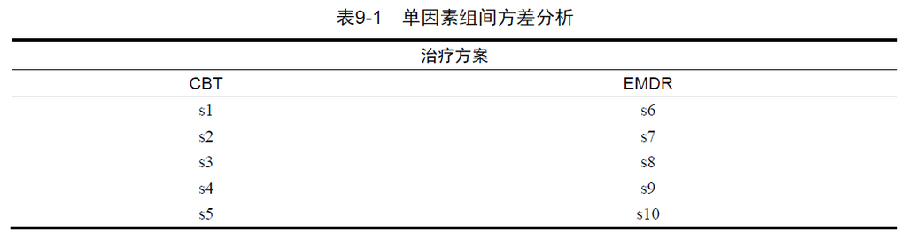

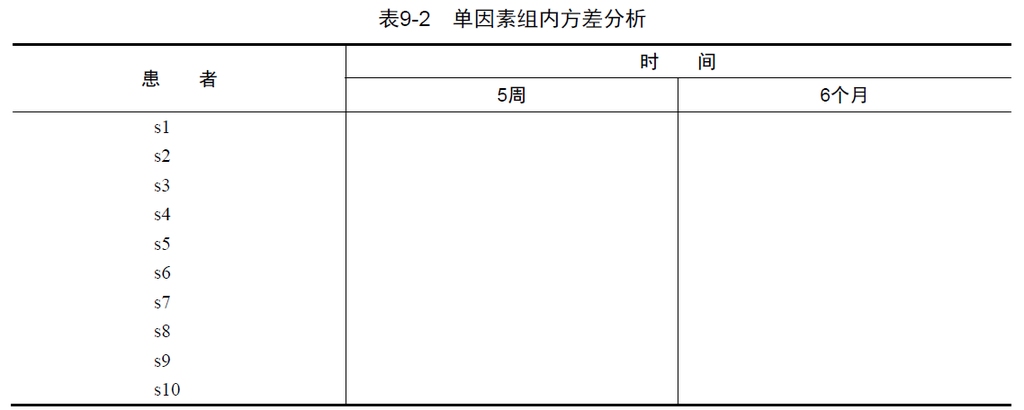

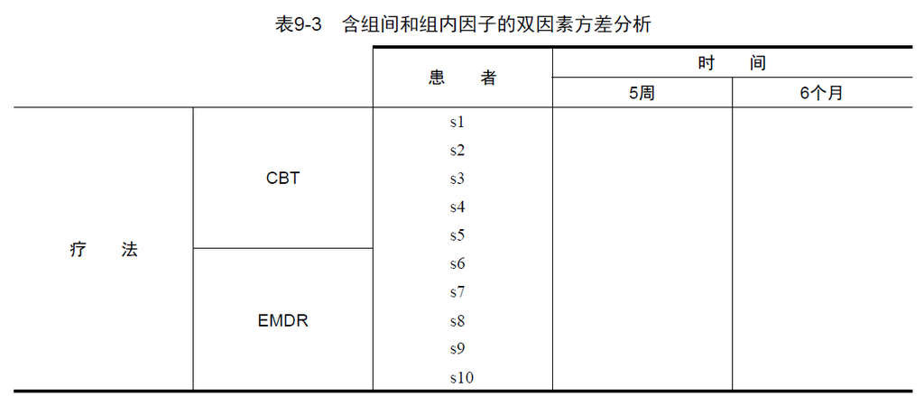

ANCOVA: covariance analysis

MANOVA: multivariate analysis of variance

MANCOVA: multivariate analysis of covariance

# 7.2 aov(formula, data=dataframe)

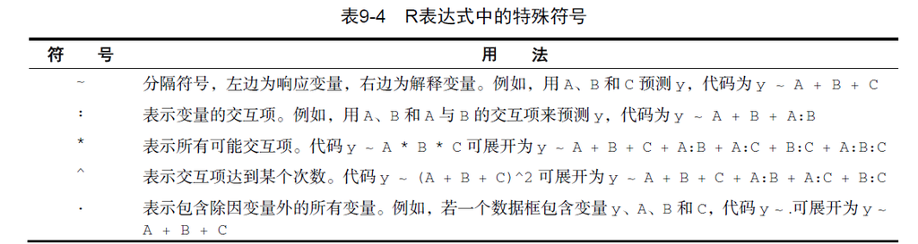

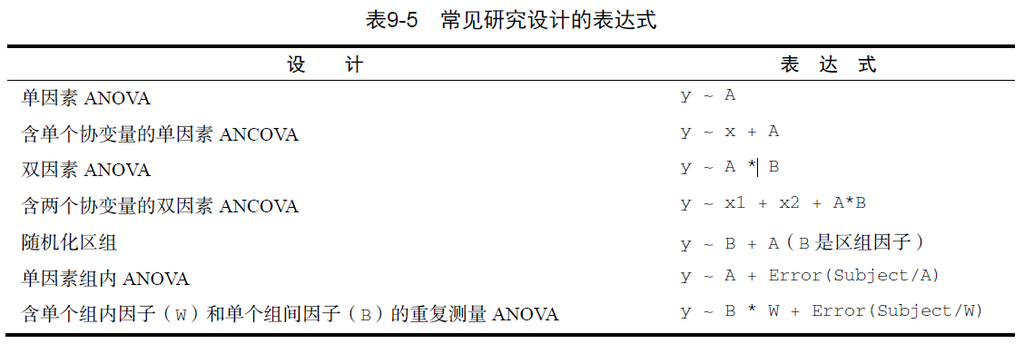

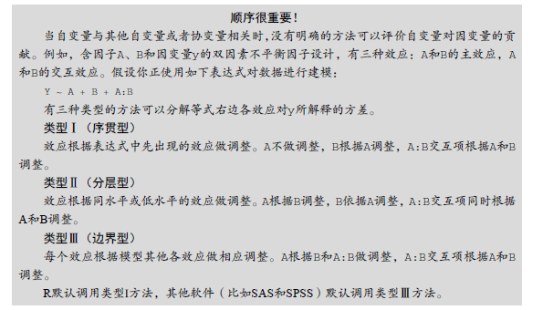

**Type I: R.cov()**

**Type III: R.Anova(), SAS, SPSS**

# 7.3 One-way ANOVA

### 7.3.1 Assess the conditions for hypothesis testing

```r
# Assessing normality
library(car)
library(multcomp)
attach(cholesterol)
#trt: treatment group; response: cholesterol reduction.
levels(trt)
```

```
## [1] "1time"  "2times" "4times" "drugD"  "drugE"
```

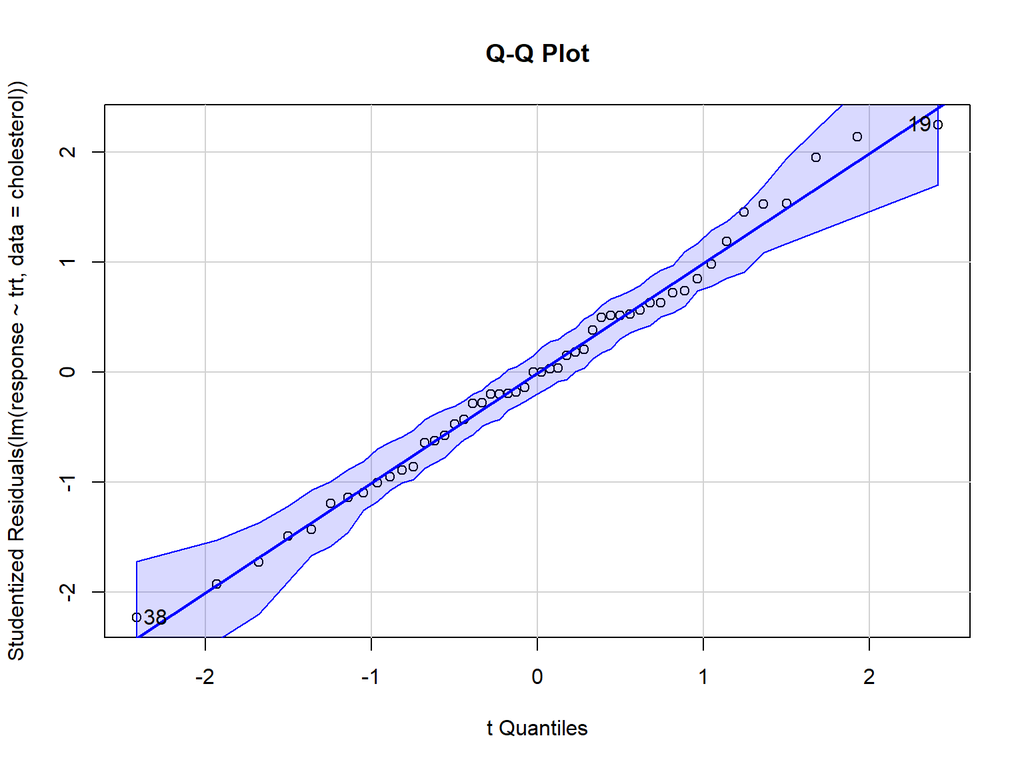

```
## [1] 19 38
```

```r
qqPlot(lm(response ~ trt, data=cholesterol),
       simulate=TRUE, main="Q-Q Plot", labels=FALSE)
```

```r
# Assessing homogeneity of variances
bartlett.test(response ~ trt, data=cholesterol)
```

```
##
##  Bartlett test of homogeneity of variances
##
## data:  response by trt
## Bartlett's K-squared = 0.57975, df = 4, p-value = 0.9653
```

```r
detach(cholesterol)
```

# 7.3.2 ANOVA

```r
library(multcomp)
attach(cholesterol)
table(trt)
```

```
## trt
##  1time 2times 4times  drugD  drugE
##     10     10     10     10     10
```

```r
aggregate(response, by=list(trt), FUN=mean)
```

```
##   Group.1        x
## 1   1time  5.78197
## 2  2times  9.22497
## 3  4times 12.37478
## 4   drugD 15.36117
## 5   drugE 20.94752
```

```r
aggregate(response, by=list(trt), FUN=sd)
```

```
##   Group.1        x
## 1   1time 2.878113
## 2  2times 3.483054
## 3  4times 2.923119
## 4   drugD 3.454636
## 5   drugE 3.345003
```

```r
fit <- aov(response ~ trt)
summary(fit)
```

```
##             Df Sum Sq Mean Sq F value   Pr(>F)
## trt          4 1351.4   337.8   32.43 9.82e-13 ***
## Residuals   45  468.8    10.4
## ---
## Signif. codes:  0 '***' 0.001 '**' 0.01 '*' 0.05 '.' 0.1 ' ' 1
```

```r
detach(cholesterol)
```

# 7.3.3 Multiple comparisons

```r
#TukeyHSD
TukeyHSD(fit)
```

```
##   Tukey multiple comparisons of means
##     95% family-wise confidence level
##
## Fit: aov(formula = response ~ trt)
##
## $trt
##                   diff        lwr       upr     p adj
## 2times-1time   3.44300 -0.6582817  7.544282 0.1380949
## 4times-1time   6.59281  2.4915283 10.694092 0.0003542
## drugD-1time    9.57920  5.4779183 13.680482 0.0000003
## drugE-1time   15.16555 11.0642683 19.266832 0.0000000
## 4times-2times  3.14981 -0.9514717  7.251092 0.2050382
## drugD-2times   6.13620  2.0349183 10.237482 0.0009611
## drugE-2times  11.72255  7.6212683 15.823832 0.0000000
## drugD-4times   2.98639 -1.1148917  7.087672 0.2512446
## drugE-4times   8.57274  4.4714583 12.674022 0.0000037
## drugE-drugD    5.58635  1.4850683  9.687632 0.0030633
```

# 7.4 One-way ANCOVA

```r
data(litter, package="multcomp")
attach(litter)
#dose: dose level;
#gesttime: gestation time as covariate;
#weight: response variable: average post-birth weights in the entire litter.
table(dose)
```

```
## dose
##   0   5  50 500
##  20  19  18  17
```

```r
aggregate(weight, by=list(dose=dose), FUN=mean)
```

```
##   dose        x
## 1    0 32.30850
## 2    5 29.30842
## 3   50 29.86611
## 4  500 29.64647
```

```r
fit <- aov(weight ~ gesttime + dose)
summary(fit)
```

```
##             Df Sum Sq Mean Sq F value  Pr(>F)
## gesttime     1  134.3  134.30   8.049 0.00597 **
## dose         3  137.1   45.71   2.739 0.04988 *
## Residuals   69 1151.3   16.69
## ---
## Signif. codes:  0 '***' 0.001 '**' 0.01 '*' 0.05 '.' 0.1 ' ' 1
```

```r
library(effects)
effect("dose", fit)
```

```
##
##  dose effect
## dose
##        0        5       50      500
## 32.35367 28.87672 30.56614 29.33460
```

# 7.5 Two-way ANOVA

```r
attach(ToothGrowth)
#len: numeric   Tooth length
#supp: Supplement type (VC or OJ).
#dose: numeric  Dose in milligrams/day
table(supp,dose)
```

```
##     dose
## supp 0.5  1  2
##   OJ  10 10 10
##   VC  10 10 10
```

```r
aggregate(len, by=list(supp,dose), FUN=mean)
```

```
##   Group.1 Group.2     x
## 1      OJ     0.5 13.23
## 2      VC     0.5  7.98
## 3      OJ     1.0 22.70
## 4      VC     1.0 16.77
## 5      OJ     2.0 26.06
## 6      VC     2.0 26.14
```

```r
aggregate(len, by=list(supp,dose), FUN=sd)
```

```
##   Group.1 Group.2        x
## 1      OJ     0.5 4.459709
## 2      VC     0.5 2.746634
## 3      OJ     1.0 3.910953
## 4      VC     1.0 2.515309
## 5      OJ     2.0 2.655058
## 6      VC     2.0 4.797731
```

```r
dose <- factor(dose)
fit <- aov(len ~ supp*dose) # fit1<- aov(len~supp+dose+supp:dose)
summary(fit)
```

```
##             Df Sum Sq Mean Sq F value   Pr(>F)
## supp         1  205.4   205.4  15.572 0.000231 ***
## dose         2 2426.4  1213.2  92.000  < 2e-16 ***
## supp:dose    2  108.3    54.2   4.107 0.021860 *
## Residuals   54  712.1    13.2
## ---
## Signif. codes:  0 '***' 0.001 '**' 0.01 '*' 0.05 '.' 0.1 ' ' 1
```

# 7.6 Repeated measures ANOVA with one between and within groups factor

```r
#conc: a numeric vector of ambient carbon dioxide concentrations.
#Treatment: a factor with levels nonchilled chilled.
#uptake: a numeric vector of carbon dioxide uptake rates.
#Type: a factor with levels Quebec Mississippi giving the origin of the plant.
#a unique identifier for each plant.
CO2$conc <- factor(CO2$conc)
CO2
```

```
## Grouped Data: uptake ~ conc | Plant
##    Plant        Type  Treatment conc uptake
## 1    Qn1      Quebec nonchilled   95   16.0
## 2    Qn1      Quebec nonchilled  175   30.4
## 3    Qn1      Quebec nonchilled  250   34.8
## 4    Qn1      Quebec nonchilled  350   37.2
## 5    Qn1      Quebec nonchilled  500   35.3
## 6    Qn1      Quebec nonchilled  675   39.2
## 7    Qn1      Quebec nonchilled 1000   39.7
## 8    Qn2      Quebec nonchilled   95   13.6
## 9    Qn2      Quebec nonchilled  175   27.3
## 10   Qn2      Quebec nonchilled  250   37.1
## 11   Qn2      Quebec nonchilled  350   41.8
## 12   Qn2      Quebec nonchilled  500   40.6
## 13   Qn2      Quebec nonchilled  675   41.4
```

[output cut: 71 more lines]

```r
w1b1 <- subset(CO2, Treatment=='chilled')
fit <- aov(uptake ~ (conc*Type) + Error(Plant/(conc)), w1b1)
summary(fit)
```

```
##
## Error: Plant
##           Df Sum Sq Mean Sq F value  Pr(>F)
## Type       1 2667.2  2667.2   60.41 0.00148 **
## Residuals  4  176.6    44.1
## ---
## Signif. codes:  0 '***' 0.001 '**' 0.01 '*' 0.05 '.' 0.1 ' ' 1
##
## Error: Plant:conc
##           Df Sum Sq Mean Sq F value   Pr(>F)
## conc       6 1472.4  245.40   52.52 1.26e-12 ***
## conc:Type  6  428.8   71.47   15.30 3.75e-07 ***
## Residuals 24  112.1    4.67
## ---
## Signif. codes:  0 '***' 0.001 '**' 0.01 '*' 0.05 '.' 0.1 ' ' 1
```

# 7.7 One-way MANOVA

```r
library(MASS)
attach(UScereal)
shelf <- factor(shelf)
levels(shelf)
```

```
## [1] "1" "2" "3"
```

```r
y <- cbind(calories, fat, sugars)
y
```

```
##        calories       fat    sugars
##  [1,] 212.12121 3.0303030 18.181818
##  [2,] 212.12121 3.0303030 15.151515
##  [3,] 100.00000 0.0000000  0.000000
##  [4,] 146.66667 2.6666667 13.333333
##  [5,] 110.00000 0.0000000 14.000000
##  [6,] 173.33333 2.6666667 10.666667
##  [7,] 134.32836 1.4925373  8.955224
##  [8,] 134.32836 0.0000000  7.462687
##  [9,] 160.00000 2.6666667 16.000000
## [10,]  88.00000 1.6000000  0.800000
## [11,] 160.00000 4.0000000 12.000000
## [12,] 220.00000 4.0000000 14.000000
## [13,] 110.00000 1.0000000 13.000000
## [14,] 110.00000 0.0000000  3.000000
```

[output cut: 51 more lines]

```r
aggregate(y, by=list(shelf), FUN=mean)
```

```
##   Group.1 calories       fat    sugars
## 1       1 119.4774 0.6621338  6.295493
## 2       2 129.8162 1.3413488 12.507670
## 3       3 180.1466 1.9449071 10.856821
```

```r
cov(y)
```

```
##            calories       fat     sugars
## calories 3895.24210 60.674383 180.380317
## fat        60.67438  2.713399   3.995474
## sugars    180.38032  3.995474  34.050018
```

```r
fit <- manova(y ~ shelf)
summary(fit)
```

```
##           Df Pillai approx F num Df den Df    Pr(>F)
## shelf      2 0.4021   5.1167      6    122 0.0001015 ***
## Residuals 62
## ---
## Signif. codes:  0 '***' 0.001 '**' 0.01 '*' 0.05 '.' 0.1 ' ' 1
```

```r
summary.aov(fit)
```

```
##  Response calories :
##             Df Sum Sq Mean Sq F value    Pr(>F)
## shelf        2  50435 25217.6  7.8623 0.0009054 ***
## Residuals   62 198860  3207.4
## ---
## Signif. codes:  0 '***' 0.001 '**' 0.01 '*' 0.05 '.' 0.1 ' ' 1
##
##  Response fat :
##             Df Sum Sq Mean Sq F value  Pr(>F)
## shelf        2  18.44  9.2199  3.6828 0.03081 *
## Residuals   62 155.22  2.5035
## ---
## Signif. codes:  0 '***' 0.001 '**' 0.01 '*' 0.05 '.' 0.1 ' ' 1
##
##  Response sugars :
##             Df  Sum Sq Mean Sq F value   Pr(>F)
## shelf        2  381.33 190.667  6.5752 0.002572 **
## Residuals   62 1797.87  28.998
## ---
## Signif. codes:  0 '***' 0.001 '**' 0.01 '*' 0.05 '.' 0.1 ' ' 1
```

# 7.8 Robust one-way MANOVA

If neither multivariate normality nor variance-covariance mean assumptions were met, a nonparametric MANOVA was considered.

```r
library(rrcov)
Wilks.test(y,shelf, method="mcd")  # this can take a while
```

```
##
##  Robust One-way MANOVA (Bartlett Chi2)
##
## data:  x
## Wilks' Lambda = 0.51073, Chi2-Value = 24.0339, DF = 4.9506, p-value =
## 0.0002042
## sample estimates:
##   calories       fat    sugars
## 1 119.8210 0.7010828  5.663143
## 2 128.0407 1.1849576 12.537533
## 3 160.8604 1.6524559 10.352646
```